# 1. Discrete Time Signals

## 3.4. Sinusoid Signals

Discrete-time sinusoids are typically of the form:

$$ x[n] = \cos(\omega n + \phi) \quad \text{or} \quad x[n] = \sin(\omega n + \phi) $$

where:

- $\omega$ is the angular frequency, measured in radians/sample
- $\phi$ is the phase, measured in radians

**Example**

- $\cos (\omega n)$

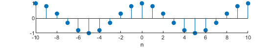

- $\sin (\omega n)$

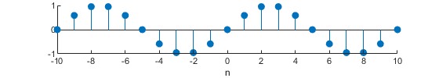

### 3.4.1 Frequency of a Sinusoid

The frequency $\omega$ controls the rate of oscillation:

- $\omega = 0$ leads to a constant signal: $\cos(0 \cdot n) = 1$
- Larger values of $\omega$ correspond to faster oscillations
- The signal is periodic if $\omega / 2\pi$ is rational

**Example**:

- $\cos (0 n)$

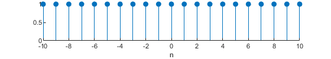

- $\cos \left(\frac{2\pi}{10} n \right)$

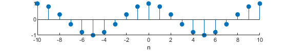

- $\cos \left(\frac{4\pi}{10} n \right)$

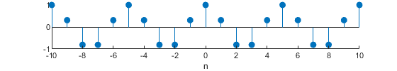

- $\cos \left(\frac{6\pi}{10} n \right)$

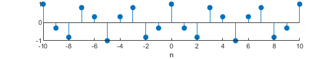

- $\cos \left(\frac{10\pi}{10} n \right)=\cos(\pi n)$

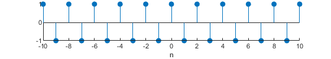

### 3.4.2 Phase of a Sinusoid

The phase $\phi$ introduces a horizontal shift in the sinusoid

- It offsets the waveform relative to $n = 0$
- It is independent of frequency

**Example**

- $\cos \left( \frac{2\pi}{10}\right)$

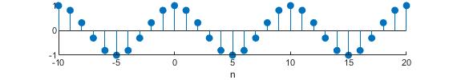

- $\cos \left( \frac{2\pi}{10} - \frac{\pi}{2}\right)$

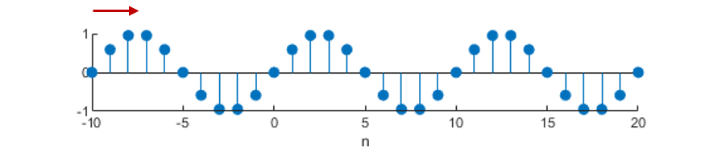

- $\cos \left( \frac{2\pi}{10} - \frac{2\pi}{2}\right)$

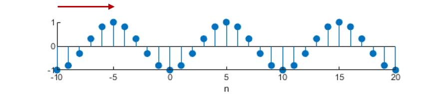

- $\cos \left( \frac{2\pi}{10} - \frac{3\pi}{2}\right)$

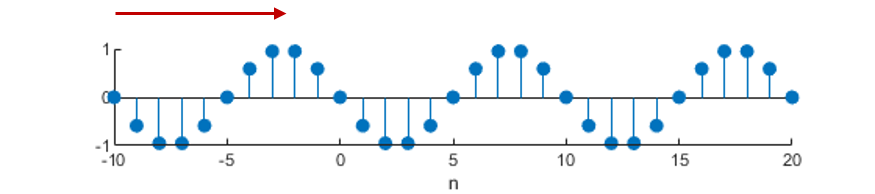

- $\cos \left( \frac{2\pi}{10} - \frac{4\pi}{2}\right) = \cos \left( \frac{2\pi}{10}\right)$

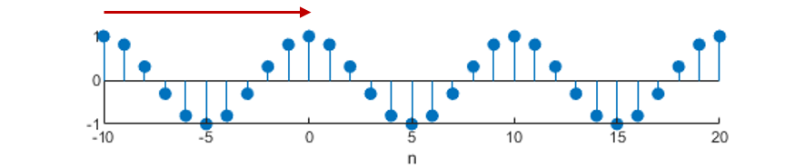

# 4. Discrete Signal Synthesis

## 4.1. Key Functions for Signal Synthesis

The following functions are commonly used to manipulate discrete-time signals in a modular and reusable way:

**sigshift(x, m, n0)**

Time-shifts the signal $x[n]$ by $n_0$ samples

$$ y[n] = x[n - n_0] $$

Input:

- x: Signal samples
- m: Time indices corresponding to x
- n0: Shift amount (positive for delay, negative for advance)

Output: Shifted signal and its new time indices

```
function [y,n] = sigshift(x,m,n0)
% implements y(n) = x(n-n0)
% [y,n] = sigshift(x,m,n0)

n = m + n0;
y = x;
```

**sigfold(x, n)**

$$ y[n] = x[-n] $$

This operation reflects the signal about the vertical axis at $n = 0$.

```
function [y, n_folded] = sigfold(x, n)
%SIGFOLD  Time-reverses a discrete-time signal
%   [y, n_folded] = sigfold(x, n) reflects the signal x(n) about n = 0
%   such that y(n) = x(-n)
%
%   Inputs:
%     x  - input signal vector
%     n  - time index vector corresponding to x
%
%   Outputs:
%     y         - time-reversed signal
%     n_folded  - time index vector for y

y = fliplr(x);           % reverse signal values
n_folded = -fliplr(n);   % reverse and negate time indices
end
```

**sigadd(x1, n1, x2, n2)**

$$y[n] = x_1[n] + x_2[n]$$

- Works even when signals are defined over different ranges.
- Properly aligns the signals to a common index vector before summing.

```
function [y, n] = sigadd(x1, n1, x2, n2)
%SIGADD  Adds two discrete-time signals with possibly different index ranges
%
%   [y, n] = sigadd(x1, n1, x2, n2) computes the sum y(n) = x1(n) + x2(n)
%   over the union of the index ranges n1 and n2.
%
%   Inputs:
%     x1, n1 - first signal and its time indices
%     x2, n2 - second signal and its time indices
%
%   Outputs:
%     y      - resulting summed signal
%     n      - time index vector corresponding to y

% Determine the full range of output indices
n_start = min([min(n1), min(n2)]);
n_end   = max([max(n1), max(n2)]);
n = n_start:n_end;

% Initialize zero-padded signals
y1 = zeros(1, length(n));
y2 = zeros(1, length(n));

y1(find((n >= min(n1)) & (n <= max(n1)) == 1)) = x1;     % x1 with duration of y
y2(find((n >= min(n2)) & (n <= max(n2)) == 1)) = x2;     % x2 with duration of y

y = y1 + y2;                                             % sequence addition
```

**sigmult(x1, n1, x2, n2)**

$$y[n] = x_1[n] \cdot x_2[n]$$

where the two signals are first aligned to a common time index vector, zero-padded if needed, and then multiplied element by element.

```
function [y, n] = sigmult(x1, n1, x2, n2)
%SIGMULT  Multiplies two discrete-time signals with possibly different index ranges
%
%   [y, n] = sigmult(x1, n1, x2, n2) computes the pointwise product
%   y(n) = x1(n) * x2(n) over the union of the index ranges n1 and n2.
%
%   Inputs:
%     x1, n1 - first signal and its time indices
%     x2, n2 - second signal and its time indices
%
%   Outputs:
%     y      - resulting product signal
%     n      - time index vector corresponding to y

% Define the full range of time indices
n_start = min([min(n1), min(n2)]);
n_end   = max([max(n1), max(n2)]);
n = n_start:n_end;

% Initialize zero-padded signals
y1 = zeros(1, length(n));
y2 = zeros(1, length(n));

y1(find(( n>= min(n1)) & (n <= max(n1)) == 1)) = x1;     % x1 with duration of y
y2(find(( n>= min(n2)) & (n <= max(n2)) == 1)) = x2;     % x2 with duration of y

y = y1 .* y2;                                            % sequence multiplication
```

(MATLAB) Example

$$ \begin{align*} x[n]=\{1,2,&\;3,4,5,6,7,6,5,4,3,2,1\}\\ &\uparrow \end{align*} $$
$$x_1[n]=2x[n-5]-3x[n+4]$$

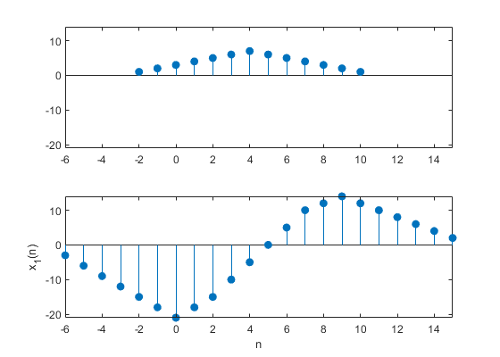

```matlab
%plot -s 560,400

n = -2:10;
x = [1:7,6:-1:1];

[x11,n11] = sigshift(x,n,5);
[x12,n12] = sigshift(x,n,-4);
[x1,n1] = sigadd(2*x11,n11,-3*x12,n12);

subplot(2,1,1), stem(n,x,'filled'), xlim([-6,15]), ylim([-21,14])
subplot(2,1,2), stem(n1,x1,'filled'), axis tight
xlabel('n'), ylabel('x_1(n)')
```

(MATLAB) Example

$$\begin{align*} x[n]=\{1,2,&\;3,4,5,6,7,6,5,4,3,2,1\}\\ &\uparrow \end{align*}$$
$$x_2[n]=x[3-n]+x[n]x[n-2]$$

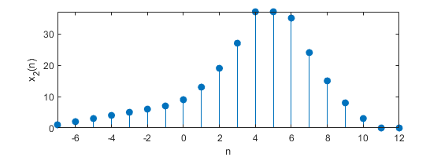

```matlab
%plot -s 560,200

[x21,n21] = sigfold(x,n);
[x21,n21] = sigshift(x21,n21,3);

[x22,n22] = sigshift(x,n,2);
[x22,n22] = sigmult(x,n,x22,n22);

[x2,n2] = sigadd(x21,n21,x22,n22);

stem(n2,x2,'filled'), axis tight
xlabel('n'), ylabel('x_2(n)')
```

## 4.2. Understanding Time Reversal and Shifting

In discrete-time signal processing, time-reversal and shifting are two fundamental operations. Combinations like $x[-n + k]$ can be understood by decomposing the operations step-by-step.

**Original Signal**

Let the signal $x[n]$ be defined as:

$$ \begin{align*} x[n] = \{ & 0,\; 1,\; 2,\; 3,\; 0,\; 0,\; 0 \} \\ & \uparrow \\ & n = 0 \end{align*} $$

This means:

- $x[0] = 0$
- $x[1] = 1$, $x[2] = 2$, $x[3] = 3$, and so on.

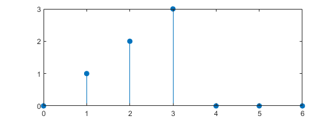

```matlab
%plot -s 560,200

N = 7;
x = [0 1 2 3 0 0 0];
n = 0:N-1;

stem(n,x,'filled')
```

**Time Reversal**

$$x_1[n] = x[-n]$$

This operation reflects the signal around $n = 0$. The time indices are reversed:

- $x[0] \to x_1[0]$, $x[1] \to x_1[-1]$, $x[2] \to x_1[-2]$, etc.

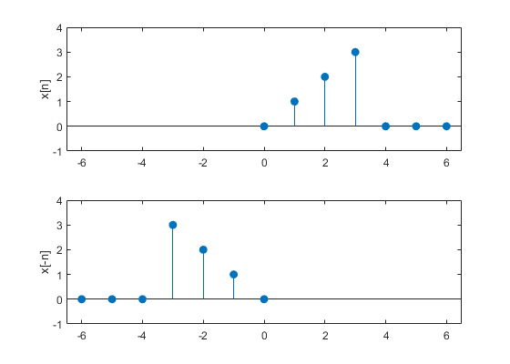

```matlab
%plot -s 560,400
[x1,n1] = sigfold(x,n);

subplot(2,1,1), stem(n,x,'filled')
ylabel('x[n]'), axis([-6.5 6.5 -1 4])
subplot(2,1,2), stem(n1,x1,'filled')
ylabel('x[-n]'), axis([-6.5 6.5 -1 4])
```

**Time Shift**

This shifts the signal to the right by 2 samples (delay):

$$ x_2[n] = x[n - 2] $$

- $x_2[2] = x[0]$, $x_2[3] = x[1]$, etc.

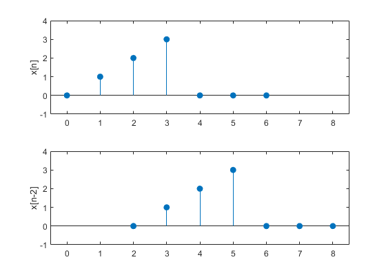

```matlab
%plot -s 560,400
[x2,n2] = sigshift(x,n,2);

subplot(2,1,1), stem(n,x,'filled')
ylabel('x[n]'), axis([-0.5 8.5 -1 4])
subplot(2,1,2), stem(n2,x2,'filled')
ylabel('x[n-2]'), axis([-0.5 8.5 -1 4])
```

**Combined Reversal and Shift**

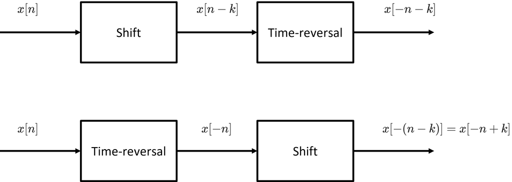

(1) A right shift by $k$ followed by a time-reversal

$$x[n] \quad \rightarrow \quad x[n - k] \quad \rightarrow \quad x[-n-k]$$

(2) A time-reversal followed by a right shift by $k$

$$x[n] \quad \rightarrow \quad x[-n] \quad \rightarrow \quad x[-(n-k)] = x[-n + k]$$

(MATLAB) Example

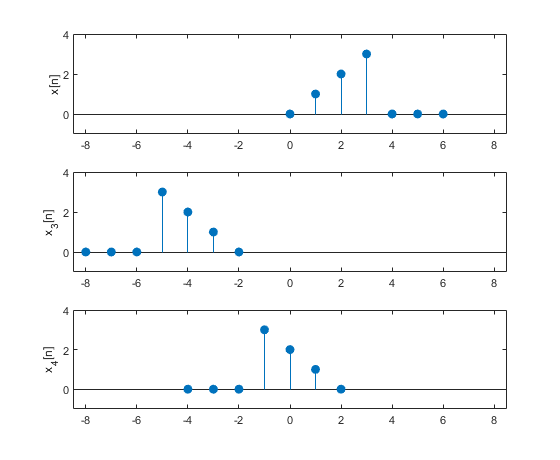

```matlab
%plot -s 560,460

[x2,n2] = sigshift(x,n,2);
[x3,n3] = sigfold(x2,n2);

[x1,n1] = sigfold(x,n);
[x4,n4] = sigshift(x1,n1,2);

subplot(3,1,1), stem(n,x,'filled')
ylabel('x[n]'), axis([-8.5 8.5 -1 4])
subplot(3,1,2), stem(n3,x3,'filled')
ylabel('x_3[n]'), axis([-8.5 8.5 -1 4])
subplot(3,1,3), stem(n4,x4,'filled')
ylabel('x_4[n]'), axis([-8.5 8.5 -1 4])
```

# 5. Complex Sinusoids

## 5.1 Complex Numbers

A complex number can be expressed in rectangular form as:

$$ z_1 = a_1 + b_1 i, \qquad \vec{z}_1 = \begin{bmatrix} a_1 \\ b_1 \end{bmatrix} $$
$$ z_2 = a_2 + b_2 i, \qquad \vec{z}_2 = \begin{bmatrix} a_2 \\ b_2 \end{bmatrix} $$

**Addition**

Addition of complex numbers is performed component-wise:

$$ \begin{align*} z &= z_1 + z_2 = (a_1 + a_2) + (b_1 + b_2)i \\ \vec{z} &= \vec{z}_1 + \vec{z}_2 = \begin{bmatrix} a_1 + a_2 \\ b_1 + b_2 \end{bmatrix} \end{align*} $$

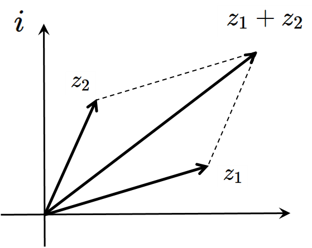

**Multiplication and Division**

When written in polar form, complex numbers take the form:

$$ \begin{cases} z_1 = r_1 e^{i\theta_1} \\ z_2 = r_2 e^{i\theta_2} \end{cases} $$

Their product and quotient are given by:

$$ \begin{cases} z_1 \cdot z_2 = r_1 r_2 e^{i(\theta_1 + \theta_2)} \\ \displaystyle \frac{z_1}{z_2} = \frac{r_1}{r_2} e^{i(\theta_1 - \theta_2)} \end{cases} $$

**Euler’s Formula**

A fundamental identity that connects exponential and trigonometric functions is Euler’s formula:

$$ e^{i\theta} = \cos\theta + i\sin\theta $$

Using Euler’s formula, any complex number can be expressed as:

$$ \begin{align*} \vec{z} &= r \cos\theta + i r \sin\theta \\ &= r (\cos\theta + i \sin\theta) \\ &= r e^{i\theta} \end{align*} $$

where:

- $r$ is the magnitude or modulus
- $\theta$ is the phase or argument

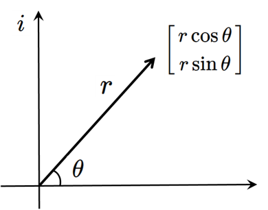

**Signal Representations in $\mathbb{C}$**

When the signal $x[n]$ is complex-valued ($x[n] \in \mathbb{C}$), it can be expressed in two equivalent forms:

- Rectangular form:

  $$ x[n] = \text{Re}\{x[n]\} + j\,\text{Im}\{x[n]\} $$
- Polar form:

  $$ x[n] = |x[n]| e^{j \angle x[n]} $$

These two views give complementary insights:

- The rectangular form separates real and imaginary components
- The polar form emphasizes amplitude and phase

Example for $e^{j \omega t}$

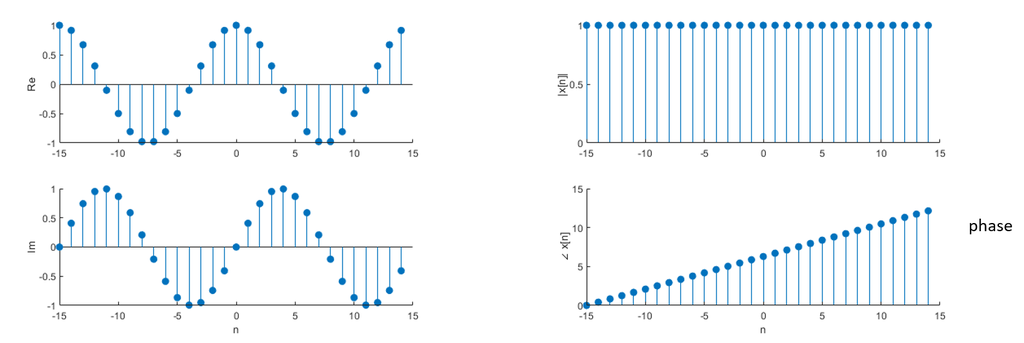

## 5.2. Geometric Interpretation of $e^{i\theta}$

The complex exponential $e^{i\theta}$ has a clear geometric meaning:

$$ e^{i\theta} = \cos\theta + i\sin\theta $$

This expression represents a point on the unit circle in the complex plane, located at an angle $\theta$ (radians) measured counterclockwise from the positive real axis.

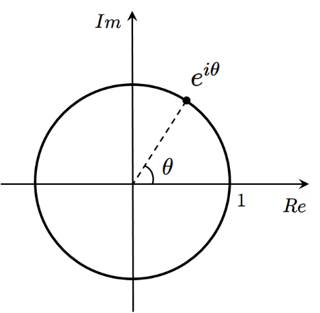

**Rotation in Time**

Let $\theta = \omega t$, where $\omega$ is angular frequency (in radians per second) and $t$ is time. Then:

$$ e^{i\omega t} $$

represents a point that rotates counterclockwise on the unit circle with angular velocity $\omega$.

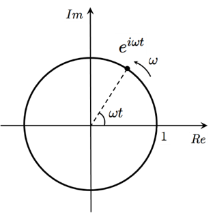

**Direction of Rotation: $e^{-i\omega t}$**

The negative exponent $e^{-i\omega t}$ has a similar form:

$$ e^{-i\omega t} = \cos(\omega t) - i\sin(\omega t) $$

This corresponds to clockwise rotation on the unit circle with angular velocity $\omega$.

If $\omega > 0$:

- $e^{i\omega t}$ rotates counterclockwise
- $e^{-i\omega t}$ rotates clockwise

## 5.3. Sinusoidal Functions from Circular Motion

A complex exponential traces out a helix in time. When plotted in the complex plane, the signal:

$$ x(t) = e^{i\omega t} $$

corresponds to a circular motion with constant angular velocity. The real and imaginary parts give sinusoidal signals:

- $\text{Re}\{e^{i\omega t}\} = \cos(\omega t) \quad \rightarrow \quad$ projection onto the real axis
- $\text{Im}\{e^{i\omega t}\} = \sin(\omega t) \quad \rightarrow \quad$ projection onto the imaginary axis

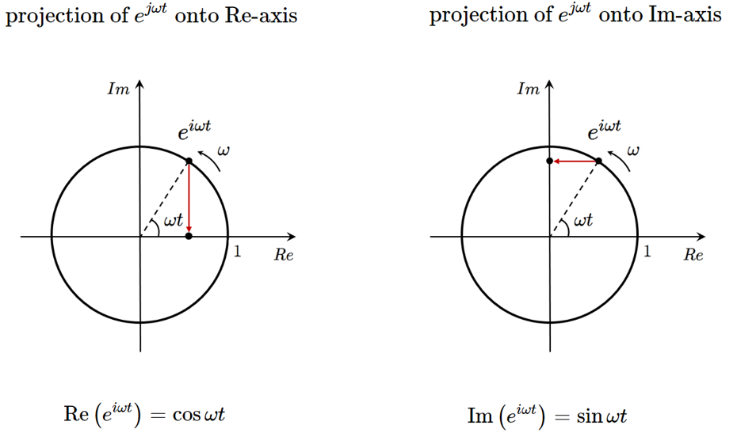

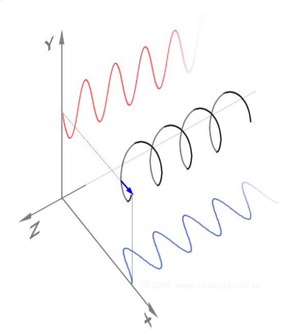

From Euler's formula, we can express real-valued sinusoids using complex exponentials:

$$ \cos(\omega t) = \frac{e^{i\omega t} + e^{-i\omega t}}{2} $$

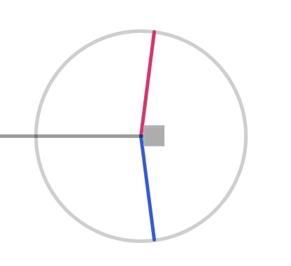

Similarly:

$$ \sin(\omega t) = \frac{e^{i\omega t} - e^{-i\omega t}}{2i} $$

These identities allow us to express real signals as linear combinations of complex exponentials, which is fundamental in Fourier analysis.

# 6. Discrete Sinusoids

A **discrete-time sinusoid** is a function of the form:

$$x[n] = A \cos(\omega_0 n + \phi)$$

or equivalently,

$$x[n] = A e^{j (\omega_0 n + \phi)}$$

where:

- $A$ is the amplitude
- $\omega_0$ is the angular frequency (radians/sample)
- $\phi$ is the initial phase

In many applications, the frequency is expressed as:

$$ \omega_0 = \frac{2\pi}{N}k $$

for some integer $k$, especially when working with signals of length $N$.

## 6.1. Aliasing of Sinusoids

Let us consider two complex sinusoids with different angular frequencies:

$$ \begin{align*} x_1[n] &= e^{j(\omega n + \phi)} \\ x_2[n] &= e^{j((\omega + 2\pi)n + \phi)} = e^{j(\omega n + \phi)} \cdot e^{j 2\pi n} \end{align*} $$

Note that $e^{j 2\pi n} = 1$ for all integer $n$. Therefore:

$$ x_2[n] = x_1[n] \quad \forall n \in \mathbb{Z} $$

Thus, even though $\omega$ and $\omega + 2\pi$ are different, the signals $x_1[n]$ and $x_2[n]$ are identical. This is called **aliasing**.

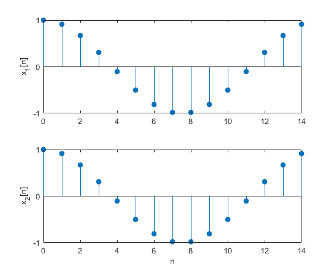

```matlab
% plot -s 560,400

N = 15;
n = 0:N-1;

x1 = cos(2*pi/N*n);
x2 = cos((2*pi/N + 2*pi)*n);

subplot(2,1,1), stem(n,x1,'filled'), yticks([-1,0,1]), ylabel('x_1[n]')
subplot(2,1,2), stem(n,x2,'filled'), yticks([-1,0,1])
xlabel('n'), ylabel('x_2[n]')
```

**Alias-free frequencies**

- Aliasing occurs when different frequencies produce the same discrete-time signal
- In discrete time, the complex exponential $e^{j\omega n}$ is $2\pi$-periodic in $\omega$

Therefore, we only need to consider a **fundamental frequency interval of length $2\pi$**

Common choices for the alias-free frequency interval:

$$ \begin{aligned} \text{(Unipolar)} \quad & 0 \leq \omega < 2\pi \\ \text{(Symmetric)} \quad & -\pi < \omega \leq \pi \end{aligned} $$

Any frequency outside this interval is an alias of one within it.

[figure not shown]

```matlab
%plot -s 560,600

N = 8;
n = 0:N-1;

xn1 = cos(pi*n);
xn2 = cos(3/2*pi*n);

t = 0:0.1:N-1;

x1 = cos(pi*t);
x2 = cos(3/2*pi*t);
x3 = cos(1/2*pi*t);

subplot(3,1,1),
stem(n,xn1,'filled'), hold on
plot(t,x1,'--','color',[0, 0.4470, 0.7410]), hold off
axis([0,7,-1.5 1.5])
ylabel('x_1[n]', 'fontsize', 12)

subplot(3,1,2),
stem(n,xn2,'filled'), hold on
plot(t,x2,'--','color',[0, 0.4470, 0.7410]), hold off
axis([0,7,-1.5 1.5])
ylabel('x_2[n]', 'fontsize', 12)

subplot(3,1,3),
stem(n,xn2,'filled'), hold on
plot(t,x2,'--','color',[0, 0.4470, 0.7410])
plot(t,x3,'color','r'), hold off
axis([0,7,-1.5 1.5])
ylabel('x_3[n]', 'fontsize', 12)
```

## 6.2. Low and High Frequencies

Consider the discrete complex sinusoid:

$$ x[n] = e^{j(\omega n + \phi)} $$

- When $\omega$ is close to 0, the signal oscillates slowly $\rightarrow$ a low frequency
- When $\omega$ is close to $\pi$ or $-\pi$, the signal oscillates rapidly $\rightarrow$ a high frequency

**Note**: The maximum frequency in discrete-time signals occurs when

$$ \omega = \pi \; \text{radians/sample} $$

This corresponds to the fastest possible oscillation in a discrete signal, where the samples alternate every step:

$$ x[n] = \cos(\pi n) = (-1)^n $$

Frequencies beyond $\pi$ radians/sample are aliases of frequencies within the interval $[-\pi, \pi]$ due to the $2\pi$-periodicity of discrete-time sinusoids.

**Example**:

Low frequencies: $\omega$ closed to $0$ and $2\pi$, (here $\omega = \frac{ 2 \pi \cdot 1}{20} = \frac{2\pi}{20}$)

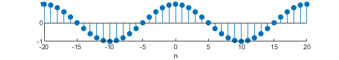

High frequencies: $\omega$ closed to $\pi$ and $-\pi$, (here $\omega = \frac{2 \pi \cdot 9}{20} = \frac{18\pi}{20}$)

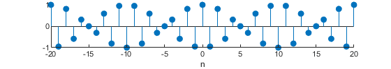

**Key Question**

Which signal has higher frequency?

$$\omega_0 = \pi ~~~ \text{or} ~~~ \omega_0 = \frac{3\pi}{2}$$

Check which one oscillates faster.

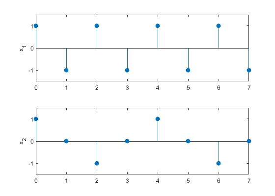

```matlab
m%plot -s 560,400

N = 8;
n = 0:N-1;

x1 = cos(pi*n);
x2 = cos(3/2*pi*n);

subplot(2,1,1), stem(n,x1,'filled'), axis([0,7,-1.5 1.5]), ylabel('x_1')
subplot(2,1,2), stem(n,x2,'filled'), axis([0,7,-1.5 1.5]), ylabel('x_2')
```

## 6.3. Frequency in Discrete Sinusoids

$$0 \; \rightarrow \; \frac{1}{8}\pi \; \rightarrow \; \frac{2}{8}\pi \; \rightarrow \; \frac{8}{8}\pi$$

As $\omega$ increases:

- The signal completes more cycles in the same number of samples.
- Oscillation rate increases.

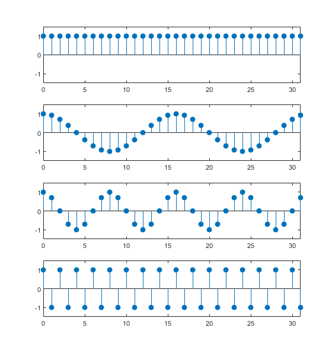

```matlab
%plot -s 560,600

N = 32;
n = 0:N-1;
x1 = cos(0*pi*n);
x2 = cos(1/8*pi*n);
x3 = cos(2/8*pi*n);
x4 = cos(1*pi*n);

subplot(4,1,1), stem(n,x1,'filled'), axis([0,31,-1.5 1.5])
subplot(4,1,2), stem(n,x2,'filled'), axis([0,31,-1.5 1.5])
subplot(4,1,3), stem(n,x3,'filled'), axis([0,31,-1.5 1.5])
subplot(4,1,4), stem(n,x4,'filled'), axis([0,31,-1.5 1.5])
```

$$2\pi \; \rightarrow \; \frac{15}{8}\pi \; \rightarrow \; \frac{14}{8}\pi \; \rightarrow \; \frac{8}{8}\pi$$

As $\omega$ decreases from $2\pi$ to $\pi$, the sinusoids become higher in frequency because their aliased equivalents approach $-\pi$.

$$ 0 \; \rightarrow \; -\frac{1}{8}\pi \; \rightarrow \; -\frac{2}{8}\pi \; \rightarrow \; -\frac{8}{8}\pi$$

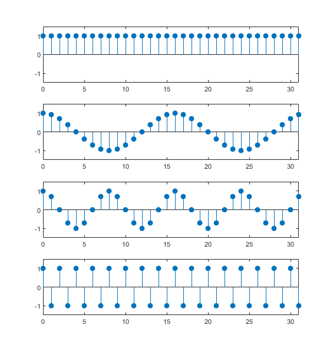

```matlab
%plot -s 560,600

N = 32;
n = 0:N-1;
x5 = cos(2*pi*n);
x6 = cos(15/8*pi*n);
x7 = cos(14/8*pi*n);
x8 = cos(1*pi*n);

subplot(4,1,1), stem(n,x5,'filled'), axis([0,31,-1.5 1.5])
subplot(4,1,2), stem(n,x6,'filled'), axis([0,31,-1.5 1.5])
subplot(4,1,3), stem(n,x7,'filled'), axis([0,31,-1.5 1.5])
subplot(4,1,4), stem(n,x8,'filled'), axis([0,31,-1.5 1.5])
```

## 6.4. Aliasing

In discrete-time signal processing, aliasing is the phenomenon where distinct continuous-time frequencies become indistinguishable after sampling. This is due to the periodic nature of complex exponentials in the discrete-time domain.

If you continue increasing frequency beyond $\pi$, the waveform begins to slow down, as it wraps back around due to periodicity.

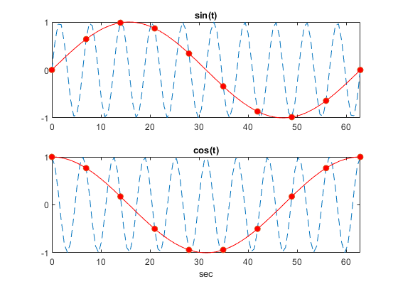

```matlab
%plot -s 560,400

t = linspace(0,10*2*pi,100);
x = sin(t);
y = cos(t);

ts = linspace(0,10*2*pi,10);
xs = sin(ts);
ys = cos(ts);

tc = linspace(0,10*2*pi,100);
xc = sin(1/10*tc);
yc = cos(1/10*tc);

subplot(2,1,1), plot(t,x,'--'), hold on
plot(ts,xs,'o','markerfacecolor','r'),
plot(tc,xc,'r-'), hold off
title('sin(t)')
yticks([-1,0,1])
xlim([0,10*2*pi])
subplot(2,1,2), plot(t,y,'--'), hold on
plot(ts,ys,'o','markerfacecolor','red'),
plot(tc,yc,'r'), hold off
xlabel('sec'), title('cos(t)')
yticks([-1,0,1])
xlim([0,10*2*pi])
```

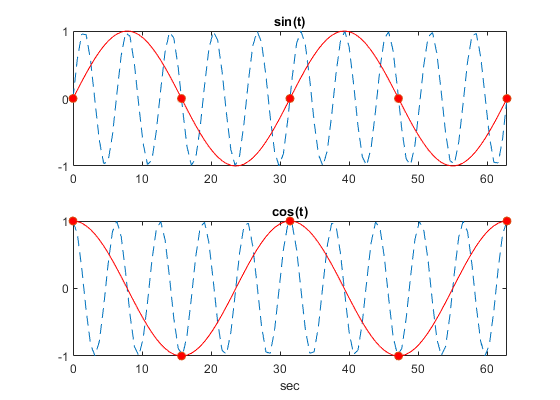

```matlab
%plot -s 560,400

t = linspace(0,10*2*pi,100);
x = sin(t);
y = cos(t);

ts = linspace(0,10*2*pi,5);
xs = sin(ts);
ys = cos(ts);

tc = linspace(0,10*2*pi,100);
xc = sin(1/5*tc);
yc = cos(1/5*tc);

subplot(2,1,1), plot(t,x,'--'), hold on
plot(ts,xs,'o','markerfacecolor','r'),
plot(tc,xc,'r-'), hold off
title('sin(t)')
yticks([-1,0,1])
xlim([0,10*2*pi])
subplot(2,1,2), plot(t,y,'--'), hold on
plot(ts,ys,'o','markerfacecolor','red'),
plot(tc,yc,'r'), hold off
xlabel('sec'), title('cos(t)')
yticks([-1,0,1])
xlim([0,10*2*pi])
```

The wagon wheel effect refers to the phenomenon where a wheel (e.g., on a wagon or car) appears to rotate slowly, stand still, or even spin backwards when filmed or viewed under discrete sampling.

```matlab
from IPython.display import YouTubeVideo
YouTubeVideo('jHS9JGkEOmA', width = "560", height = "315")
```

[video not shown]

# 7. Signal Visualization

**Harmonic Sinusoids**

The harmonic sinusoids are complex exponentials of the form:

$$ x[n] = e^{j \frac{2\pi}{N}kn} $$

where:

- $k \in \mathbb{Z}$ is the harmonic index
- $N \in \mathbb{Z}^+$ is the period of the signal

These sinusoids are called harmonic because their frequencies are integer multiples of a fundamental frequency:

$$ \omega_k = \frac{2\pi k}{N} = \frac{2\pi }{N}k $$

**Periodicity of Harmonic Sinusoids**

Let

$$ x[n] = e^{j(\omega n + \phi)} \quad \text{with} \quad \omega = \frac{2\pi k}{N} $$

This is a harmonic sinusoid, where:

- $k$ is an integer (harmonic index)
- $N$ is the signal period (number of samples per cycle)

We can show that $x[n]$ is periodic with period $N$:

$$ x[n + N] = e^{j\omega(n + N) + j\phi} = e^{j\omega n + j\phi} \cdot e^{j\omega N} = x[n] \cdot e^{j\cdot 2\pi k} = x[n] $$

Since $e^{j\cdot 2\pi k} = 1$, the signal repeats every $N$ samples.

## 7.1. Visualizing the Harmonic Sinusoidals

$$x[n] = e^{j \omega n }, \qquad \omega = \frac{2 \pi}{N}k$$

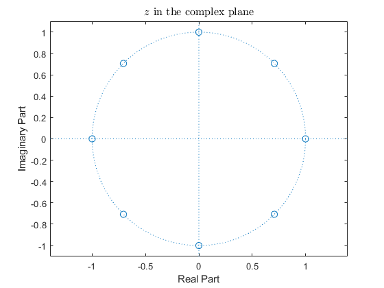

```matlab
%plot -s 560,420

N = 8;
k = 1;
w = 2*pi/N*k;
z1 = exp(1j*w);

n = 0:N-1;
z = (z1.^n).';

zplane(z)
title(['$z~{\rm in~the~complex~plane}$'],'interpreter','LaTeX','fontsize',12);
```

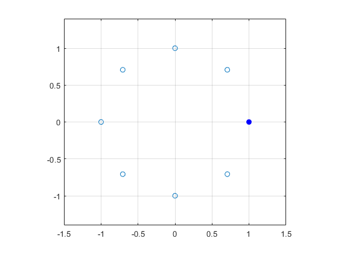

```matlab
%plot -s 560,420

k = 3;

N = 8;
n = 0:N-1;

xp = exp(1j*2*pi/N*k*n);
x = exp(1j*2*pi/N*k*0);

plot(real(xp),imag(xp),'o'), hold on
plot(real(x),imag(x),'o', 'MarkerFaceColor','b', 'MarkerEdgeColor','b'), hold off
grid on
axis equal; axis([-1.5, 1.5,-1.4 1.4])
```

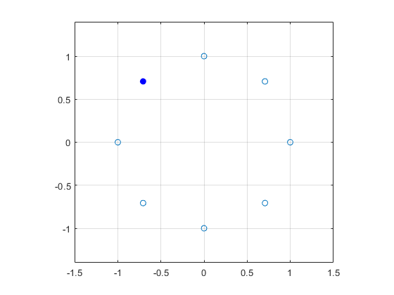

```matlab
%plot -s 560,420

x = exp(1j*2*pi/N*k*1);

plot(real(xp),imag(xp),'o'), hold on
plot(real(x),imag(x),'o', 'MarkerFaceColor','b', 'MarkerEdgeColor','b'), hold off
grid on
axis equal; axis([-1.5, 1.5,-1.4 1.4])
```

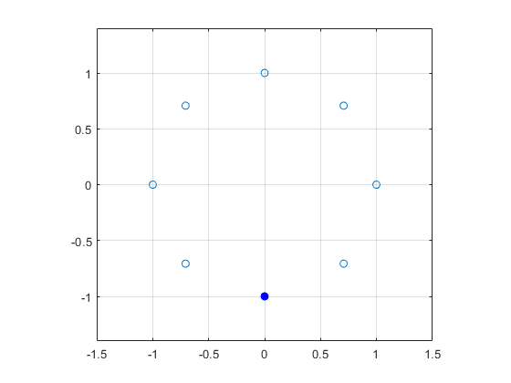

```matlab
%plot -s 560,420

x = exp(1j*2*pi/N*k*2);

plot(real(xp),imag(xp),'o'), hold on
plot(real(x),imag(x),'o', 'MarkerFaceColor','b', 'MarkerEdgeColor','b'), hold off
grid on
axis equal; axis([-1.5, 1.5,-1.4 1.4])
```

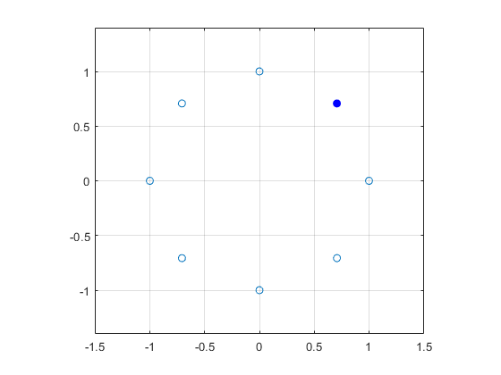

```matlab
%plot -s 560,420

x = exp(1j*2*pi/N*k*3);

plot(real(xp),imag(xp),'o'), hold on
plot(real(x),imag(x),'o', 'MarkerFaceColor','b', 'MarkerEdgeColor','b'), hold off
grid on
axis equal; axis([-1.5, 1.5,-1.4 1.4])
```

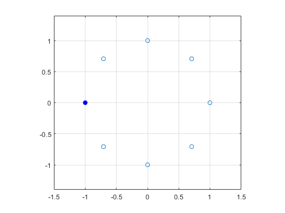

```matlab
%plot -s 560,420

x = exp(1j*2*pi/N*k*4);

plot(real(xp),imag(xp),'o'), hold on
plot(real(x),imag(x),'o', 'MarkerFaceColor','b', 'MarkerEdgeColor','b'), hold off
grid on
axis equal; axis([-1.5, 1.5,-1.4 1.4])
```

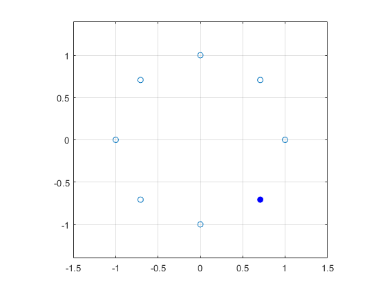

```matlab
%plot -s 560,420

x = exp(1j*2*pi/N*k*5);

plot(real(xp),imag(xp),'o'), hold on
plot(real(x),imag(x),'o', 'MarkerFaceColor','b', 'MarkerEdgeColor','b'), hold off
grid on
axis equal; axis([-1.5, 1.5,-1.4 1.4])
```

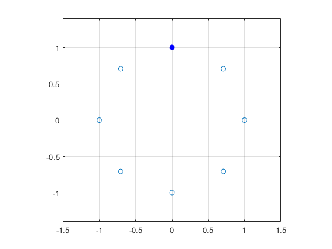

```matlab
%plot -s 560,420

x = exp(1j*2*pi/N*k*6);

plot(real(xp),imag(xp),'o'), hold on
plot(real(x),imag(x),'o', 'MarkerFaceColor','b', 'MarkerEdgeColor','b'), hold off
grid on
axis equal; axis([-1.5, 1.5,-1.4 1.4])
```

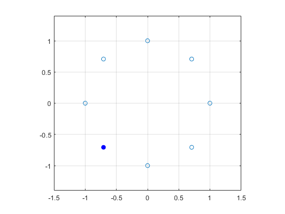

```matlab
%plot -s 560,420

x = exp(1j*2*pi/N*k*7);

plot(real(xp),imag(xp),'o'), hold on
plot(real(x),imag(x),'o', 'MarkerFaceColor','b', 'MarkerEdgeColor','b'), hold off
grid on
axis equal; axis([-1.5, 1.5,-1.4 1.4])
```

## 7.2. Visual Matrix of Harmonic Sinusoids

$$x[n] = e^{j \omega n }, \qquad \omega = \frac{2 \pi}{N}k$$

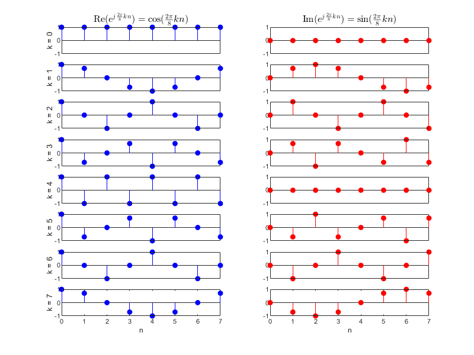

```matlab
%plot -s 800,600

N = 8;
n = 0:N-1;

for k = 0:N-1;
    x = exp(1j*(2*pi/N)*k*n);

    subplot(8,2,2*k+1)
    stem(n,real(x),'b','filled');
    xticks([])
    ylabel(['k = ',num2str(k)],'fontsize',10);
    axis([0, 7, -1, 1]);

    subplot(8,2,2*k+2)
    stem(n,imag(x),'r','filled');
    xticks([])
    axis([0, 7, -1, 1]);
end

subplot(821)
title(['${\rm Re}(e^{j \frac{2\pi}{8}kn}) = \cos(\frac{2\' ...
       'pi}{8}kn)$'],'interpreter','LaTeX','fontsize',12);

subplot(822)
title(['${\rm Im}(e^{j \frac{2\pi}{8}kn}) = \sin(\frac{2\' ...
       'pi}{8}kn)$'],'interpreter','LaTeX','fontsize',12);

subplot(8,2,15), xticks([0,1,2,3,4,5,6,7]), xlabel('n')
subplot(8,2,16), xticks([0,1,2,3,4,5,6,7]), xlabel('n')
```

**Matrix Visualization of Harmonic Sinusoids**

We define a time-frequency matrix of size $N \times N$:

$$ X[n, k] = e^{j \frac{2\pi}{N}kn} $$

where:

- $n = 0, 1, \dots, N-1$ is the time index
- $k = 0, 1, \dots, N-1$ is the frequency index (harmonic number)

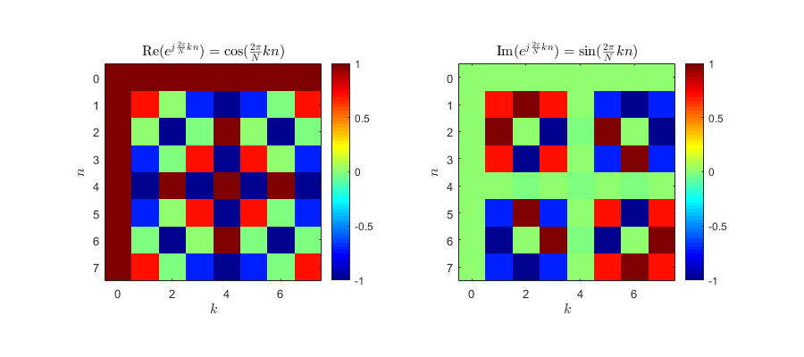

```matlab
%plot -s 900,400

N = 8;
n = 0:N-1;
for k = 0:N-1
    D(:,k+1) = exp(1j*(2*pi/N)*k*n).';
end

subplot(121), imagesc(n,n,real(D)), colormap('jet'), axis square
xlabel('$k$','interpreter','LaTeX','fontsize',12);
ylabel('$n$','interpreter','LaTeX','fontsize',12);
title('${\rm Re}(e^{j\frac{2\pi}{N}kn})=\cos(\frac{2\pi}{N}kn)$',...
'interpreter','LaTeX','fontsize',12);
colorbar

subplot(122), imagesc(n,n,imag(D)), colormap('jet'), axis square
xlabel('$k$','interpreter','LaTeX','fontsize',12);
ylabel('$n$','interpreter','LaTeX','fontsize',12);
title('${\rm Im}(e^{j\frac{2\pi}{N}kn})=\sin(\frac{2\pi}{N}kn)$',...
'interpreter','LaTeX','fontsize',12);
colorbar
```

# 8. Complex Exponential Signals with Damping

A natural generalization of the complex exponential signal is to consider exponentials of the form $z^n$, where the base $z$ is a complex number. Let:

$$ z = |z| e^{j\omega}, \qquad z \in \mathbb{C} $$

This is the polar form of a complex number, where:

- $|z|$ is the magnitude (distance from the origin in the complex plane)
- $\omega = \angle z$ is the phase angle (measured counterclockwise from the positive real axis)

The complex number $z$ can be interpreted geometrically as a point or vector in the complex plane with polar coordinates $(|z|, \omega)$.

## 8.1. Exponentiation: Spirals and Damping

When a complex number $z$ is raised to an integer power $n$, the result is:

$$ z^n = \left( |z| e^{j\omega} \right)^n = |z|^n \cdot e^{j\omega n} $$

This separates naturally into two components:

- Amplitude envelope: $|z|^n$ is a real-valued exponential term that governs the growth or decay of the signal magnitude
- Phase term*: $e^{j\omega n}$ is a complex sinusoid that determines the angular (rotational) behavior of the signal in the complex plane

**Spiral Behavior**

The signal $z^n = |z|^n e^{j\omega n}$ traces a spiral trajectory in the complex plane:

- If $|z| < 1$, the spiral decays inward toward the origin
- If $|z| > 1$, the spiral grows outward away from the origin
- If $|z| = 1$, the trajectory remains on the unit circle — a pure rotation without damping or growth

This structure is often referred to as a damped (or growing) complex sinusoid.

Note that the phase angle increases linearly with $n$, since:

$$ \text{angle}(z^n) = \omega n $$

Hence, the term $e^{j\omega n}$ traces a circle (or rotates) with constant angular velocity $\omega$.

```matlab
from IPython.display import YouTubeVideo
YouTubeVideo('vDulP6vTa9g', width = "560", height = "315")
```

[video not shown]

$$x[n]=\gamma^n e^{j\frac{2\pi}{N} n}$$

```matlab
%% real and imag parts

r = 0.95;
N = 20;
n = 0:2*N-1;
x = (r.^n).*exp(1j*2*pi/N*n);
```

**1) retangular form**

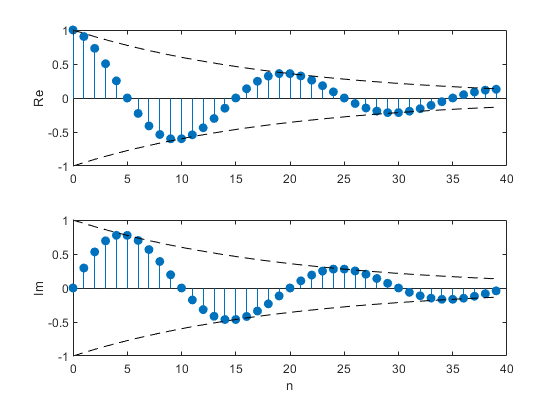

```matlab
%plot -s 560,400

subplot(2,1,1)
stem(n,real(x),'filled'), hold on
plot(n, [1;-1]*r.^n,'k--'), hold off
ylabel('Re')

subplot(2,1,2)
stem(n,imag(x),'filled'), hold on
plot(n, [1;-1]*r.^n,'k--'), hold off
ylabel('Im'), xlabel('n')
```

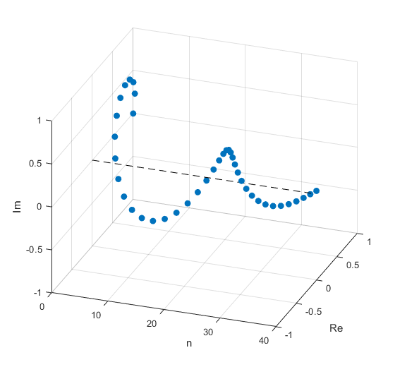

```matlab
%plot -s 560,520

c = [0, 0.4470, 0.7410];

plot3(n,real(x),imag(x),'o','MarkerFaceColor',c,'MarkerEdgeColor',c), hold on
plot3(n,zeros(size(n)),zeros(size(n)),'k--'), hold off
xlabel('n'), ylabel('Re'), zlabel('Im')
grid on
ylim([-1,1])
zlim([-1,1])
view([20,30])
```

**2) polar form**

$$ \begin{align*} x[n] &=\gamma^n e^{j\frac{2\pi}{N} n}\\ &= \lvert x[n]\lvert \, e^{j\angle x[n]} \end{align*} $$

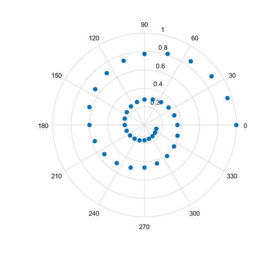

```matlab
%% polar coordinate

fig = polar(angle(x),abs(x),'o');      % theta in radian
set(fig,'MarkerFaceColor',[0, 0.4470, 0.7410],'MarkerEdgeColor',[0, 0.4470, 0.7410]);
```

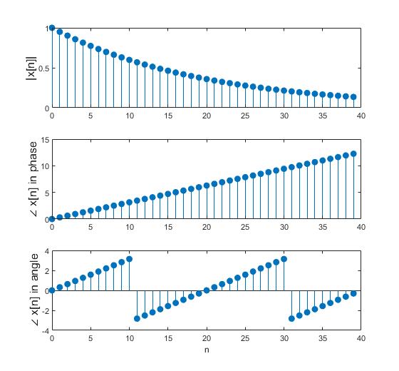

```matlab
%% polar coordinate

subplot(3,1,1)
stem(n,abs(x),'filled')
ylabel('|x[n]|','fontsize',12)

subplot(3,1,2)
stem(n,phase(x),'filled')
ylabel('\angle x[n] in phase','fontsize',12)

subplot(3,1,3)
stem(n,angle(x),'filled')
ylabel('\angle x[n] in angle','fontsize',12), xlabel('n')
```

# 9. Signals are Vectors

Discrete-time signals of finite length can be naturally represented as vectors in a vector space.

- If the signal values are real, the signal is a vector in $\mathbb{R}^N$
- If the signal values are complex, the signal is a vector in $\mathbb{C}^N$

Let $x[n]$ be a signal defined for $n = 0, 1, \dots, N-1$. Then the vector representation of $x[n]$ is:

$$ x = \begin{bmatrix} x[0] \\ x[1] \\ \vdots \\ x[N-1] \end{bmatrix} \in \mathbb{R}^N \; \text{or} \; \mathbb{C}^N $$

## 9.1. Transpose and Conjugate Transpose

In linear algebra, we frequently use transposition and conjugate transposition when working with vectors and matrices.

**Transpose (denoted by $T$)**

The transpose of a column vector is a row vector:

$$ x^T = \begin{bmatrix} x[0] & x[1] & \cdots & x[N-1] \end{bmatrix} $$

This operation does not affect the numerical values—it only changes the shape (orientation) of the vector.

**Conjugate Transpose (denoted by $H$)**

Also known as the Hermitian transpose, this operation both transposes the vector and applies the complex conjugate to each element:

$$ x^H = \begin{bmatrix} x[0]^* & x[1]^* & \cdots & x[N-1]^* \end{bmatrix} $$

This is especially important when working in $\mathbb{C}^N$, as inner products and orthogonality are defined using conjugate transposition.

```matlab
% be careful with ' in MATLAB

a = [2 + 1j, 1 - 2j];
a'
a.'
```

```
ans =

   2.0000 - 1.0000i
   1.0000 + 2.0000i


ans =

   2.0000 + 1.0000i
   1.0000 - 2.0000i
```

## 9.2. Matrix Multiplication as Linear Combination

Matrix-vector multiplication can be interpreted as a linear combination of vectors.

Let:

- $x_0, x_1, \dots, x_{M-1} \in \mathbb{R}^N$ (or $\mathbb{C}^N$) be column vectors
- $\alpha_0, \alpha_1, \dots, \alpha_{M-1} \in \mathbb{R}$ (or $\mathbb{C}$) be scalars

Then the linear combination of the vectors is:

$$ y = \alpha_0 x_0 + \alpha_1 x_1 + \cdots + \alpha_{M-1} x_{M-1} = \sum_{m=0}^{M-1} \alpha_m x_m $$

**Step-by-Step: Representing as Matrix Multiplication**

**Step 1**: Form a matrix by stacking the vectors

Let $X$ be the $N \times M$ matrix whose columns are the vectors $x_m$:

$$ X = [x_0 \mid x_1 \mid \cdots \mid x_{M-1}] $$

Each column of $X$ is one of the vectors being combined.

**Step 2**: Stack the scalar weights into a column vector

Let $\alpha$ be the $M \times 1$ vector of coefficients:

$$ \alpha = \begin{bmatrix} \alpha_0 \\ \alpha_1 \\ \vdots \\ \alpha_{M-1} \end{bmatrix} $$

**Step 3**: Matrix-vector product expresses the linear combination

$$y=\alpha_0 x_0 + \alpha_1 x_1 + \cdots + \alpha_{M-1}x_{M-1} = \sum_{m=0}^{M-1}\alpha_m x_m = [x_0 \mid x_1 \mid \cdots \mid x_{M-1}] \begin{bmatrix}\alpha_0 \\ \alpha_1 \\ \vdots \\\alpha_{M-1} \end{bmatrix} = X \alpha$$

This result $y \in \mathbb{R}^N$ (or $\mathbb{C}^N$) is a linear combination of the columns of $X$, weighted by the entries of $\alpha$.

## 9.3. Inner Product

The inner product (also called the dot product) is a fundamental operation for comparing two vectors. For discrete-time signals interpreted as vectors in $\mathbb{C}^N$, the inner product is defined as:

$$ \langle x, y \rangle = y^H x = \sum_{n=0}^{N-1} x[n]\, y[n]^* $$

Here, $y^H$ denotes the conjugate transpose of $y$, and $x[n], y[n]^*$ multiplies the $n$-th entry of $x$ by the complex conjugate of the $n$-th entry of $y$.

The inner product takes two signals and returns a single complex number. It quantifies both alignment and magnitude similarity between the signals.

**Inner Product with Itself**

When a signal is compared with itself, the result is the sum of squared magnitudes:

$$ \langle x, x \rangle = \sum_{n=0}^{N-1} x[n]\, x[n]^* = \sum_{n=0}^{N-1} |x[n]|^2 = \|x\|_2^2 $$

This is the squared $\ell_2$ norm (Euclidean energy) of the signal.

**Orthogonality**

Two signals $x, y \in \mathbb{C}^N$ are said to be orthogonal if their inner product is zero:

$$ \langle x, y \rangle = 0 $$

Orthogonality means the signals are completely uncorrelated in the vector space sense. This concept is foundational in constructing orthonormal bases, such as those used in the discrete Fourier transform.

**Example**: Two sets of orthogonal signals

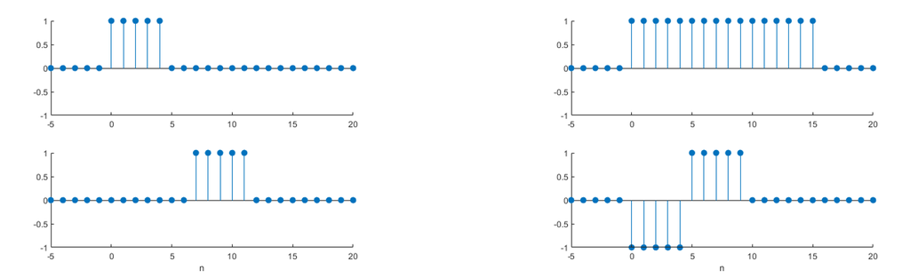

## 9.4. Harmonic Sinusoids are Orthogonal

Consider the set of discrete complex exponentials (harmonic sinusoids) defined by

$$ d_k[n] = e^{j\frac{2\pi k}{N}n}, \qquad 0 \leq n \leq N - 1, \quad 0 \leq k \leq N - 1 $$

where $k$, $n$, and $N$ are integers.

We claim that these harmonic sinusoids are mutually orthogonal over $n = 0, 1, \cdots, N-1$. That is,

$$ \langle d_k, d_l \rangle = 0 \quad \text{for} \quad k \ne l $$

This can be shown as follows:

$$ \begin{align*} \langle d_k, d_l \rangle &= \sum_{n=0}^{N-1} d_k[n] \, d_l[n]^* \\ &= \sum_{n=0}^{N-1} e^{j\frac{2\pi k}{N}n} \cdot \left(e^{j\frac{2\pi l}{N}n}\right)^* \\ &= \sum_{n=0}^{N-1} e^{j\frac{2\pi k}{N}n} \cdot e^{-j\frac{2\pi l}{N}n} \\ &= \sum_{n=0}^{N-1} e^{j\frac{2\pi}{N}(k - l)n} \end{align*} $$

Let $r = k - l \in \mathbb{Z}$. For $r \ne 0$, define $a = e^{j\frac{2\pi}{N}r}$, and observe that $a \ne 1$. Then:

$$ \sum_{n=0}^{N-1} a^n = \frac{1 - a^N}{1 - a} $$

Since $a^N = e^{j2\pi r} = 1$, the numerator becomes zero, and we have:

$$ \sum_{n=0}^{N-1} a^n = 0 \quad \Rightarrow \quad \langle d_k, d_l \rangle = 0 \quad \text{for } k \ne l $$

This confirms that the harmonic sinusoids ${d_k[n]}$ form an orthogonal set over $n = 0, \cdots, N-1$.

This property underpins many results in Fourier analysis and digital signal processing, especially in the context of the Discrete Fourier Transform (DFT).

```
innerproduct =

  -2.2572e-15
```

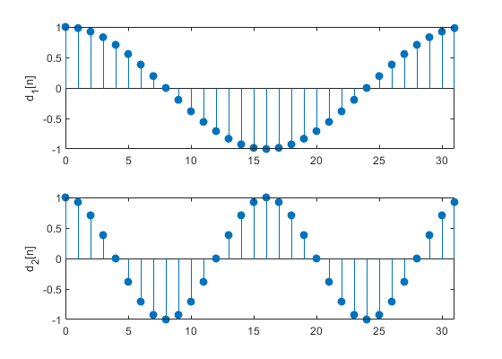

```matlab
%plot -s 560,400

N = 32;
n = 0:N-1;

k = 1;
d1 = cos(2*pi/N*k*n)';

k = 2;
d2 = cos(2*pi/N*k*n)';

subplot(211)
stem(n,d1,'filled'), ylabel('d_1[n]'), axis tight
subplot(212)
stem(n,d2,'filled'), ylabel('d_2[n]'), axis tight

% Note: in Matlab, the operation ' performs complex conjugate transpose
innerproduct = d2'*d1
```

```
innerproduct =

  -1.8965e-15 + 8.7512e-16i
```

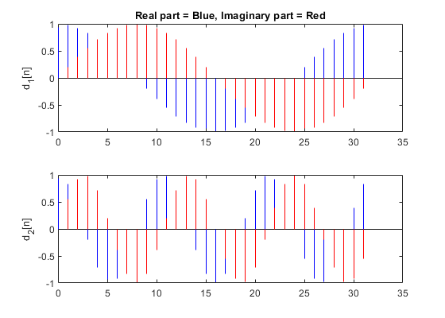

```matlab
%plot -s 560,400

N = 32;
n = 0:N-1;

k = 1;
d1 = exp(1j*2*pi/N*k*n).';

k = 3;
d2 = exp(1j*2*pi/N*k*n).';

subplot(211)
stem(n,real(d1),'b','marker','none'); hold on, ylabel('d_1[n]')
stem(n,imag(d1),'r','marker','none'); hold off
title('Real part = Blue, Imaginary part = Red','fontsize',10)

subplot(212)
stem(n,real(d2),'b','marker','none'); hold on, ylabel('d_2[n]')
stem(n,imag(d2),'r','marker','none'); hold off

% Note: in Matlab, the operation ' performs complex conjugate transpose
innerproduct = d2'*d1
```

$$d_k[n] = \frac{1}{\sqrt{N}} e^{j{2\pi k \over N}n}$$

```matlab
% to check two complex signals are orthonormal

N = 16;
n = 0:N-1;

k = 3;
s_3 = 1/sqrt(N)*exp(1j*2*pi/N*k*n).';

k = 5;
s_5 = 1/sqrt(N)*exp(1j*2*pi/N*k*n).';

% ': complex conjugate transpose
s_3'*s_5    % to see they are orthogonal
s_3'*s_3    % to see it is normalized
s_5'*s_5    % to see it is normalized
```

```
ans =

  -4.1633e-16 + 8.1780e-17i


ans =

     1


ans =

     1
```

## 9.5. Matrix Multiplication as a Sequence of Inner Products of Rows

Let $X$ be an $N \times M$ matrix and $\alpha$ an $M \times 1$ column vector. The product

$$ y = X \alpha $$

produces an $N \times 1$ output vector $y$.

Each entry $y[n]$ in the result can be interpreted as the inner product of the $n$-th row of $X$ with the vector $\alpha$.

The matrix $X$ can be written as

$$ X = \begin{bmatrix} \vdots & \vdots & & \vdots \\ x_0[n] & x_1[n] & \cdots & x_{M-1}[n] \\ \vdots & \vdots & & \vdots \end{bmatrix} $$

where the $n$-th row consists of the values $x_m[n]$ for $m = 0, 1, \cdots, M-1$.

Then the output vector is

$$ y = \begin{bmatrix} \vdots \\ y[n] \\ \vdots \end{bmatrix} = X \alpha $$

Each component of $y$ is computed as

$$ y[n] = \sum_{m=0}^{M-1} \alpha_m x_m[n] = \langle \text{row } n \text{ of } X,\; \alpha \rangle $$

This shows that matrix-vector multiplication can also be interpreted row-wise as a sequence of inner products, in contrast to the earlier column-wise interpretation as a linear combination of vectors.

```matlab
%%javascript
$.getScript('https://kmahelona.github.io/ipython_notebook_goodies/ipython_notebook_toc.js')
```